# CIS-544-HW1

Chen

October 18, 2016

### — Problem 1 —

R uses functions to perform operations. To run a function called `funcname`, we type `funcname(input1, input2)`, where the inputs (or arguments) `input1` and `input2` tell R how to run the function. A function can have any number of inputs. For example, to create a vector of numbers, we use the function `c()` (for *concatenate*). Any numbers inside the parentheses are joined together. The following command instructs R to join together the numbers 7,5,2 and 6 and to **save** them as a *vector* named `x`

```r
x<-c(7,5,2,6)   ##create the vector 7,5,2,6 and save them in to the vector x
x
```

```
## [1] 7 5 2 6
```

*Problem*: Create a vector `x` by joining the numbers 4,8 and 6 ; and a vector `y` by joining the numbers 5,3,9. Find the sum of `x` and `y` and save it in a vector `z`. Find the length of `z`. Create a vector `w` that contains the square root of every element in `z`.

```r
x<-c(4,8,6)   ##create the vector 4,8,6 and save them in to the vector x.
y<-c(5,3,9)   ##create the vector 5,3,9 and save them in to the vector y.
z=x+y      ##Add the vector x and vector y, save them into vector z.
z     ##Display the vector z.
```

```
## [1]  9 11 15
```

```r
length(z)   ##Show the length of the vector z.
```

```
## [1] 3
```

```r
w<-sqrt(z)   ##Find the square root of the vector z and save it to vector w.
w         ##show the vector w.
```

```
## [1] 3.000000 3.316625 3.872983
```

### — Problem 2 —

Create a matrix with two rows and two columns (2x2) with entries 1 and 3 in the first row, and 2 and 4 in the second row.

```r
a <- matrix(c(1,2,3,4), nrow = 2, ncol = 2, dimnames = list(c("row1", "row2"), c("Col1", "Col2")))
    ## create the 2 by 2 matrix, write the name as "row1","row2","col1","col2",use the martrix value as 1,2,3 and 4. save it to vector a.
a   ##Display the  matrix a.
```

```
##      Col1 Col2
## row1    1    3
## row2    2    4
```

### — Problem 3 —

Use the `set.seed` function with the number 3 as argument. Create a vector `y` of random normal variables (using `rnorm`) of size 100, and find its mean, variance, and standard deviation.

```r
set.seed(3)
y<-rnorm(100)   ##Create a vector y of random normal variables which size is 100
mean(y)   ##find the mean for the vector y.
```

```
## [1] 0.01103557
```

```r
var(y)    ##find the variance for the vector y.
```

```
## [1] 0.7328675
```

```r
sd(y)     ##find the standard deviation for the vector y.
```

```
## [1] 0.8560768
```

### — Problem 4 —

The `plot()` function is the primary way to plot data in R. For instance, `plot(x,y)` produces a scatter-plot of the numbers in `x` versus the numbers in `y`. There are many additional options that can be passed in to the `plot()` function. For example, passing in the argument `xlab` will result in a label on the x-axis. To find out more information about the `plot()` function, type `?plot`.

*Problem*: Create vectors `x` and `y` of random normal variables (using `rnorm`) of length 100, and plot the points $(x,y)$. Change the $x$-label so it reads “this is the x-axis”, and the $y$-label so it reads “this is the y-axis label”

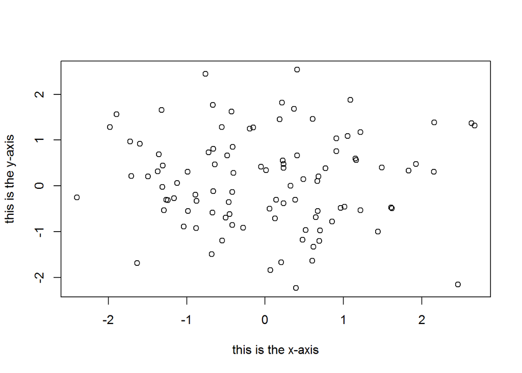

```r
x<-rnorm(100)
y<-rnorm(100)
plot(x, y, xlab="this is the x-axis", ylab="this is the y-axis")  ##Plot the graph x and y, change the label of the x axis to "this is the x-axis", and change the label of y axis to"this is the y-axis".
```

### — Problem 5 —

The function `seq()` can be used to create a sequence of numbers. For instance, `seq(a,b)` makes a vector of integers between `a` and `b`. There are many other options: for instance, `seq(0,1,length=10)` makes a sequence of 10 numbers that are equally spaced between 0 and 1. Typing `3:11` is a shorthand for `seq(3,11)` for integer arguments.

*Problem*: Create a vector `x` as the sequence of numbers between 1 and 10, and a vector `y` as the uniform sequence of numbers from $-\pi$ to $\pi$ of length 10. Let `z` be `x-y`

```r
x<-seq(1,10)
y<-seq(-pi,pi,length=10)
z<x-y
```

```
##  [1] FALSE FALSE FALSE FALSE FALSE FALSE FALSE FALSE FALSE FALSE
```

```r
z
```

```
## [1]  9 11 15
```